# Reporte BioProject Equipo 2

Leonardo González López, Yuliana Denisse Sosa Gómez

2026-05-19

# Descripción del equipo

- **Equipo:** 2
- **Integrantes:**
  - Leonardo González López (lgonzalez) - minestev17@gmail.com,
  - Yuliana Denisse Sosa Gómez (ysosa) - yuliana.sogo2006@gmail.com

# Descripción de los datos

Tabla 1: Detalles del Bioproyecto y características de las muestras

Descripción

Información

BioProject

PRJNA1198873

Especie

*Homo sapiens*

Tipo de bibliotecas

*paired-end*

Método de selección

Purificación de transcritos poliadenilados (poli-A)

Número de transcriptomas

6

Número de réplicas biológicas

3 replicas biológicas por condición (control y knockdown)

Secuenciador empleado

Illumina NovaSeq 6000

Distribución de las muestras

Profundidad de secuenciación de cada transcriptoma

19 - 24 M seq

Tamaño de las lecturas

148 bp

Artículo científico

Zhao Z, Yu P, Wang Y, Li H et al. Silencing of STEAP3 suppresses cervical cancer cell proliferation and migration via JAK/STAT3 signaling pathway. Cancer Metab 2024 Dec 30;12(1):40. PM ID: 3973 675 1

## Resumen del BioProject

Basado en el artículo “Silencing of *STEAP3* suppresses cervical cancer cell proliferation and migration via *JAK/STAT3* signaling pathway” se comparó el perfil transcripcional, a partir de secuencias en archivos FASTQ de 6 muestras de la línea celular HeLa divididas en 2 grupos, uno control y otro al que se deletó el gen *STEAP3*. Se realizó un alineamiento y conteo con STAR debido a la facilidad de trabajar con este programa ya que no se necesita crear un archivo .txi para importar los datos a R; posteriormente se realizó el análisis de expresión diferencial con DESeq2 y el enriquecimiento funcional con gProfiler2 y clusterprofiler para obtener un enriquecimiento de GO Biological Process y de KEGG pathways. Se encontraron 3 genes subregulados y 12 genes sobreexpresados, destacando los genes *SERPINB3/4* asociados a la sensibilidad al tratamiento de cáncer cervical, además el gen *STEAP3* se encuentra subregulado como era esperado. La vía de la ferrotopsis se encuentra enriquecida debido a la subregulación de *STEAP3*, la cuál está relacionada con la muerte celular, el cuál es un mecanismo comúnmente relacionado con el cáncer.

Se utilizaron todas las muestras del dataset, correspondiendo a 3 réplicas biológicas de células de la línea celular HeLA con knockdown en el gen *STEAP3*. La información se encuentra en la **Tabla 2**.

|  | muestras | condicion | SampleID | replica_biologica |
| --- | --- | --- | --- | --- |
| 1 | GSM8682795 | STEAP3 knockdown | SAMN45855841 | KD_3 |
| 2 | GSM8682794 | STEAP3 knockdown | SAMN45855842 | KD_2 |
| 3 | GSM8682793 | STEAP3 knockdown | SAMN45855843 | KD_1 |
| 4 | GSM8682792 | WT | SAMN45855844 | NC_3 |
| 5 | GSM8682791 | WT | SAMN45855845 | NC_2 |
| 6 | GSM8682790 | WT | SAMN45855846 | NC_1 |

# Diagrama de flujo de trabajo

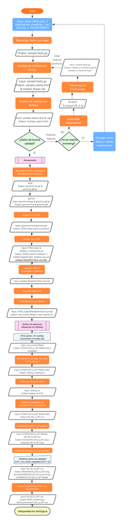

# Estructura del trabajo

La **estructura** de las carpetas dentro del GitHub se puede observar a continuación, la cual contiene carpetas compartidas con la estructura dentro del cluster:

```
├── Equipo2.Rproj                                         # Proyecto en R
├── README.md                                             # Archivo README del proyecto.
├── Reporte-Bioproject-Final.Rmd                          # Archivo con reporte documentado
├── Reporte-Bioproject-Final.html                         # Archivo renderizado del reporte (este archivo)
├── Infografia-Cientifica-Proyecto                        # Infografía Científica para el público general
├── metadata.csv                                          # Metadata de proyecto utilizada en scripts
├── figures                                               # Carpeta con imagenes usadas en reporte
│   ├── Diagrama_de_flujo.png                               # Workflow del proyecto
│   ├── Dotplot-articulo-original.jpeg                      # Dotplot artículo de referencia
│   ├── Heatmap_KD_vs_WT.png                                # Heatmap 20 genes más expresados diferencialmente
│   ├── KEGG_droplot.png                                    # Droplot con pathways KEGG más enriquecidos
│   ├── ManhattanGO_KD_vs_WT.png                            # Manhattan plot de Geno Ontology (GO)
│   ├── PCA_no_batch_rlog.png                               # PCA sin batch effect
│   ├── PCA_rlog.png                                        # PCA con batch effect
│   ├── VolcanoPlot_KD_vs_WT.png                            # Volcano Plot genes sobreexpresados y subexpresados
│   ├── VolcanoPlot-articulo-original.jpeg                  # Volcano Plot artículo de referencia
│   ├── barplotDOWN_GO_KD_vs_WT.png                         # Barplot 40 términos más subexpresados
│   ├── barplotUP_GO_KD_vs_WT.png                           # Barplot 40 términos más sobreexpresados
│   ├── fastqc_adapters_processed.png                       # Imagenes de control de calidad
│   ├── fastqc_adapters_raw.png                               # raw: antes de trimming
│   ├── fastqc_per_base_n_content_plot_processed.png          # processed: después de trimming
│   ├── fastqc_per_base_n_content_plot_raw.png
│   ├── fastqc_per_base_sequence_quality_plot_processed.png
│   ├── fastqc_per_base_sequence_quality_plot_raw.png
│   ├── fastqc_per_sequence_gc_content_plot_processed.png
│   ├── fastqc_per_sequence_gc_content_plot_raw.png
│   ├── fastqc_per_sequence_quality_scores_plot_processed.png
│   ├── fastqc_per_sequence_quality_scores_plot_raw.png
│   ├── fastqc_sequence_duplication_levels_plot_processed.png
│   ├── fastqc_sequence_duplication_levels_plot_raw.png
│   ├── fastqc_sequence_length_distribution_plot_processed.png
│   └── fastqc_sequence_length_distribution_plot_raw.png
├── out_logs                                              # Outlogs de jobs de slurm corridos en Ken
│   ├── DEG_STAR_KD1685.err
│   ├── DEG_STAR_KD1685.out
│   ├── GO_terms_STAR1687.err
│   ├── GO_terms_STAR1687.out
│   ├── Load_data_STAR_1684.err
│   ├── Load_data_STAR_1684.out
│   ├── SRR31732086.ReadsPerGene.out.tab
```

[output cut: 72 more lines]

```
└── scripts                                               # Scripts documentados del proyecto
    ├── 01_DownloadRawData.sh                               # Descarga archivos FASTQ
    ├── 02_Quality_raw.sh                                   # Reportes FastQC datos crudos
    ├── 03_Trimmed.sh                                       # Trimming datos
    ├── 04_Quality_trimmed.sh                               # Reportes FastQC datos procesados
    ├── 05_STAR_index.sh                                    # Indexado de genoma referencia
    ├── 06_STAR_align.sh                                    # Alineamiento y cuentas con STAR
    ├── 07_Load_data_STAR.R                                 # Matriz de cuentas conjunta en R
    ├── S07_Load_data_STAR.sh                               # Job slurm Script 7
    ├── 08_DEG_STAR_KD.R                                    # Corrección batch effect y análisis DEG
    ├── S08_DEG_STAR_KD.sh                                  # Job slurm Script 8
    ├── 09_Visualization_data_STAR.R                        # Genera VolcanoPlot y Heatmap
    ├── S09_Visualization_data_STAR.sh                      # Job slurm Script 9
    ├── 10_GO_terms_STAR.R                                  # Enriquecimiento de términos GO, KEGG
    └── S10_GO_terms_STAR.sh                                # Job slurm Script 10
```

## Outlogs

Los **outlogs** de los scripts se pueden observar en: [Outlogs](https://github.com/leonardoglez6/Equipo2/tree/main/out_logs).

Y, dentro del cluster, en la ruta `/mnt/data/bioinfo-estadistica-2/RNAseq_2026/equipos/Equipo2/scripts/out_logs`

## Paquetes y versiones

Los módulos utilizados dentro del cluster fueron los siguientes:

```
module load anaconda3/2025.06
⎣ source activate multiqc-1.5
module load fastqc/0.11.3
module load star/2.7.9a
module load trimmomatic/0.33
module load r/4.4.1
```

Por otro lado, los paquetes utilizados para los análisis con R fueron:

```
library(clusterProfiler) #versión 4.14.6
library(DESeq2) #versión 1.46.0
library(DOSE) #versión 4.0.1
library(dplyr) #versión 1.1.4
library(enrichplot) #versión 1.26.6
library(ggplot2) #versión 4.0.1
library(gprofiler2) #versión 0.2.4
library(org.Hs.eg.db) #versión 3.20.0
library(pheatmap) #versión 1.0.13
library(tidyverse) #versión 2.0.0
```

# Resultados

## 1. Obtener datos crudos

Buscamos nuestro BioProject dentro de ENA (European Nucleotide Archive), para poder seleccionar las muestras. Posteriormente, utilizamos el comando `wget` para las 12 muestras (6 muestras con su respectiva lectura forward y reverse).

El script correspondiente se puede encontrar dentro del GitHub, en la ruta scripts/01_DownloadRawData.sh

Los datos correspondientes, se almacenaron en el cluster, en la ruta `/mnt/data/bioinfo-estadistica-2/RNAseq_2026/equipos/Equipo2/data/raw`

## 2. Análisis de calidad de las secuencias de los datos crudos

Se realizó el análisis de calidad de las 6 muestras seleccionadas con el programa **FastQC**, primero de forma individual y después generando un MultiQC.

El script correspondiente se puede encontrar dentro del GitHub, en la ruta scripts/02_Quality_raw.sh

Los resultados del análisis de calidad, se almacenaron en el cluster, en la ruta `/mnt/data/bioinfo-estadistica-2/RNAseq_2026/equipos/Equipo2/quality1`

Se obtuvo un contenido de GC aproximado de 50% formando una distribución normal, característica de un resultado esperado de buena calidad, y una cobertura que varía del rango de 19M - 24.7M.

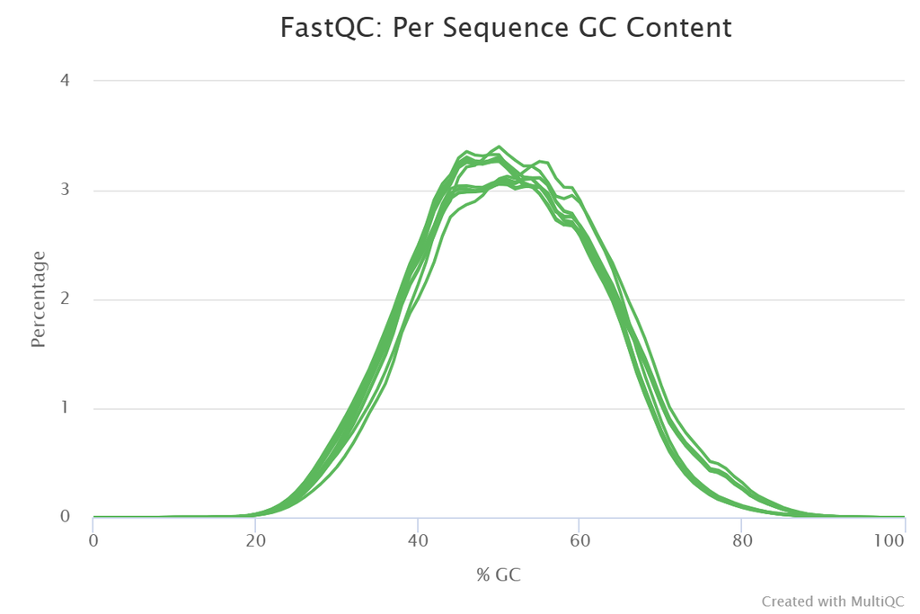

Contenido de GC de los datos crudos

Las muestras tienen una calidad óptima dentro de las posiciones de las lecturas, con valores dentro de la zona verde y un puntaje Phred superior a 35. De igual forma, las muestras tienen un promedio de calidad con un pico máximo en Phred 36.

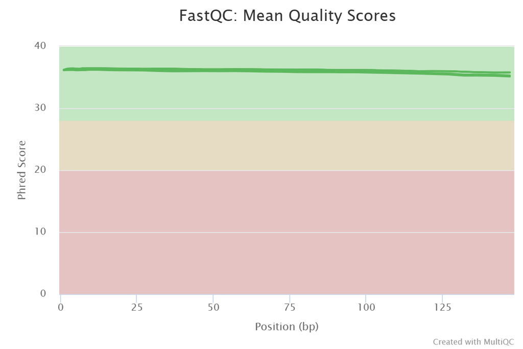

Calidad por base de los datos crudos

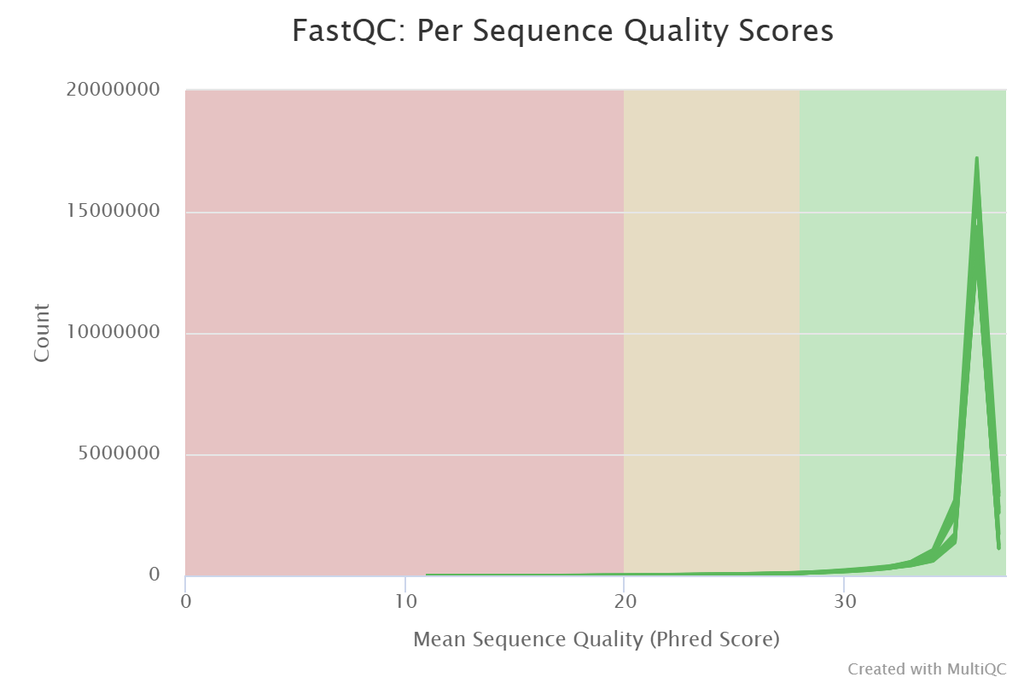

Calidad por secuencia de los datos crudos

El porcentaje de contenido de bases indeterminadas (N) en los reads superó la prueba, así como la prueba de secuencias sobrerepresentadas y no se encontraron muestras con contaminación de adaptadores.

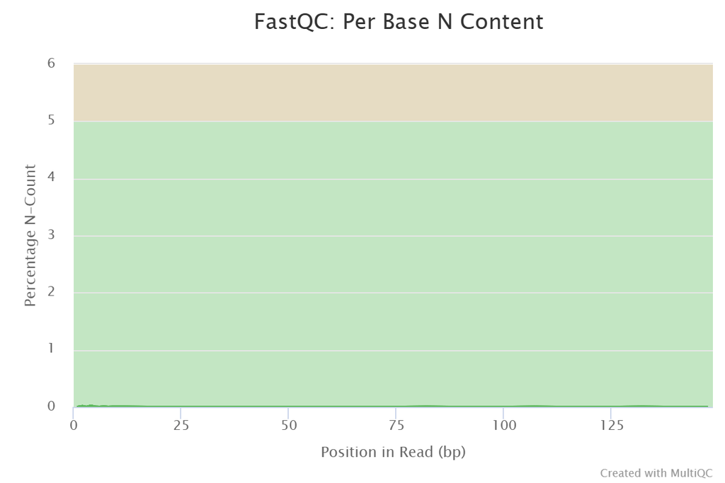

Contenido de bases indeterminadas de los datos crudos

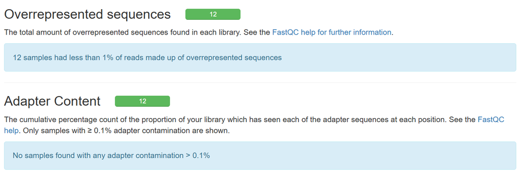

Pruebas secuencias sobrerrepresentadas y contenido de adaptadores de los datos crudos

Sin embargo, se identificaron secuencias duplicadas, que posiblemente puedan estar relacionadas con la presencia de dímeros de adaptadores.

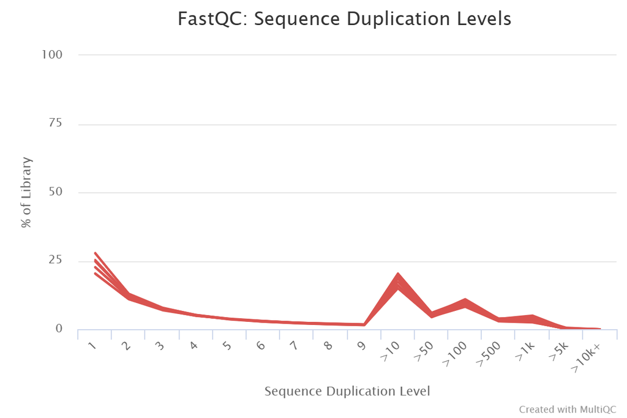

Secuencias duplicadas de los datos crudos

### Conclusión de la calidad de los datos crudos

Al terminar de analizar los datos, concluimos que son adecuados para el desarrollo del proyecto. Por lo general, las secuencias tienen buena calidad con valores Phred mayores a 30 y tienen un porcentaje de GC correcto. Además de que los posibles errores por secuencias duplicadas se podrían mejorar al remover los adaptadores.

Podemos concluir que podemos continuar utilizando esta base de datos para análisis futuros, pero debemos realizar la limpieza correspondiente para mejorar la calidad de los mismos.

## 3. Trimming de datos crudos

Se realizó el trimming de los datos para quitar secuencias de mala calidad y remover la posible presencia de adaptadores dentro de los datos.

De manera previa, se descargaron las secuencias de los adaptadores a eliminar *TruSeq3 Paired End* debido a las características de nuestros datos. Posteriormente, se utilizó el programa **Trimmomatic** con los siguientes parámetros:

- `LEADING:3` Elimina bases del inicio del read si su calidad es menor a 3
- `TRAILING:3` Elimina bases del final del read si su calidad es menor a 3
- `SLIDINGWINDOW:4:20` Recorre read con ventana de 4 bases y corta si calidad promedio es menor a 20.
- `MINLEN:80` Descarta reads con menos de 80 bases después del trimming

El script correspondiente se puede encontrar dentro del GitHub, en la ruta scripts/03_Trimmed.sh

Los datos después del trimming, se almacenaron en el cluster, en la ruta `/mnt/data/bioinfo-estadistica-2/RNAseq_2026/equipos/Equipo2/data/processed`

## 4. Análisis de calidad de las secuencias de los datos procesados

Seguido del trimming, se realizó el análisis de calidad de las 6 muestras con el programa **FastQC**, primero de forma individual y después generando un MultiQC.

El script correspondiente se puede encontrar dentro del GitHub, en la ruta scripts/04_Quality_trimmed.sh

Los resultados del análisis de calidad, se almacenaron en el cluster, en la ruta `/mnt/data/bioinfo-estadistica-2/RNAseq_2026/equipos/Equipo2/quality2`

Se obtuvo un contenido de GC aproximado de 50% formando una distribución normal, característica de un resultado esperado de buena calidad, y una cobertura que varía del rango de 17.9M - 23.2M.

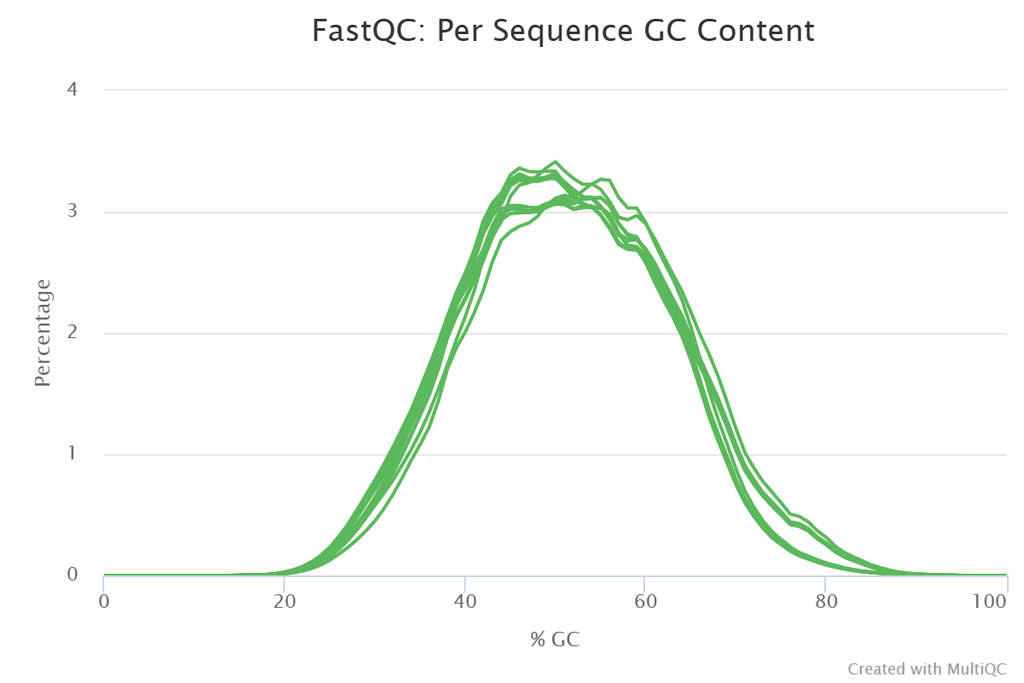

Contenido de GC de los datos procesados

Las muestras tienen una calidad óptima dentro de las posiciones de las lecturas, con valores dentro de la zona verde y un puntaje Phred superior a 36.

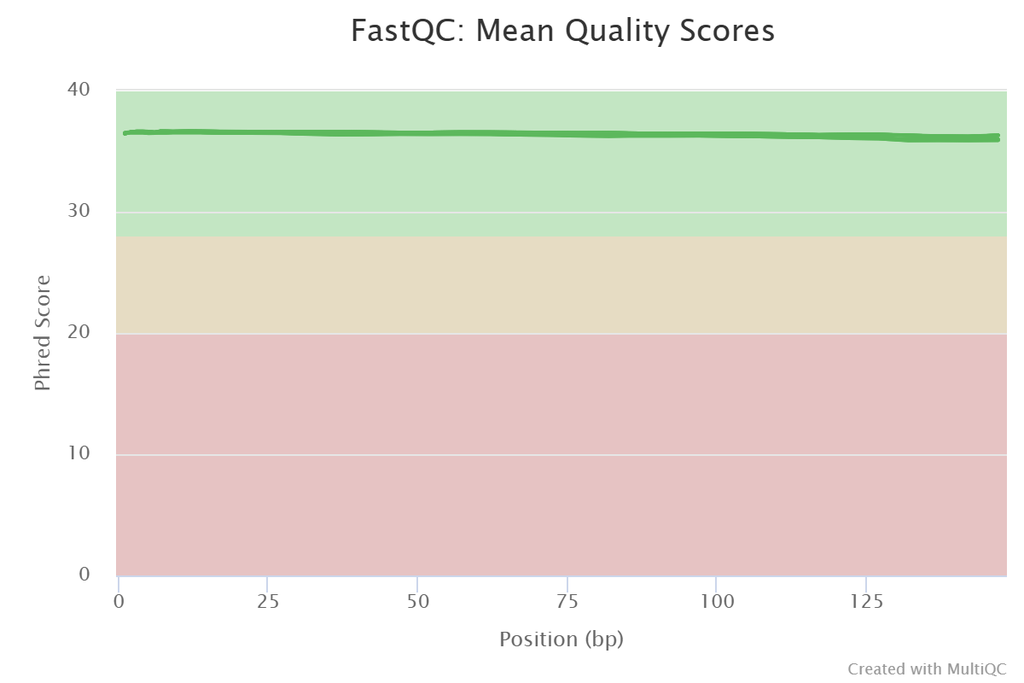

Calidad por base de los datos procesados

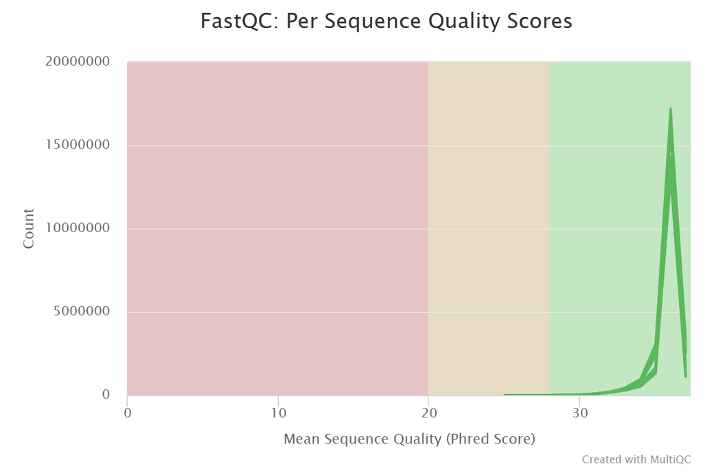

Calidad por secuencia de los datos procesados

El porcentaje de contenido de bases indeterminadas (N) en los reads superó la prueba, así como la prueba de secuencias sobrerepresentadas y no se encontraron muestras con contaminación de adaptadores los cuales fueron removidos utilizando `trimmomatic` versión 0.33. A su vez, realizar el trimming nos ayudó a quitar lecturas de mala calidad.

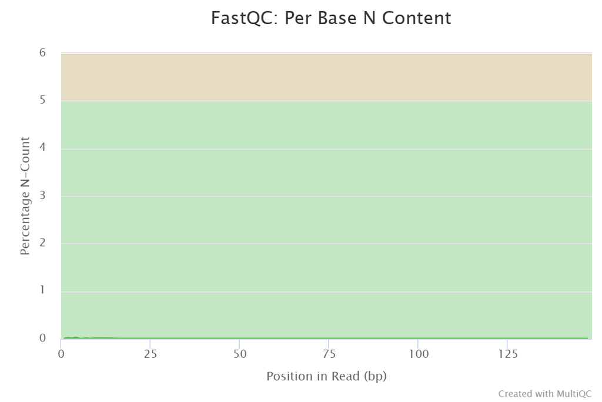

Contenido de bases indeterminadas de los datos procesados

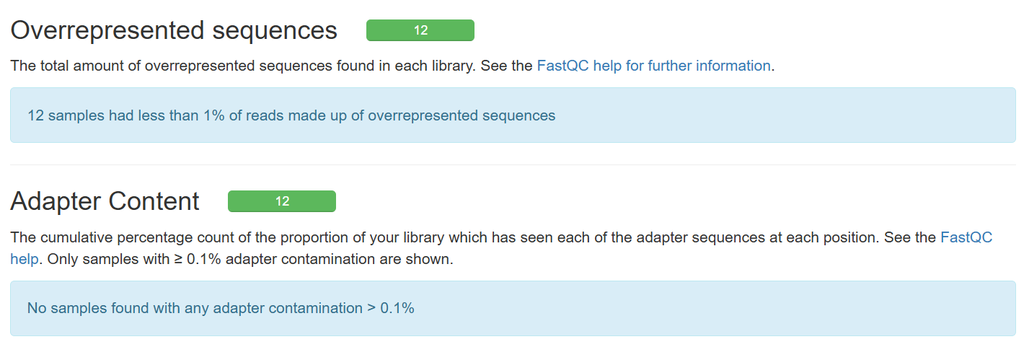

Pruebas secuencias sobrerrepresentadas y contenido de adaptadores de los datos procesados

La presencia de secuencias duplicadas se mantuvo como una prueba fallida, sin embargo, son resultados esperados al realizar RNA-seq.

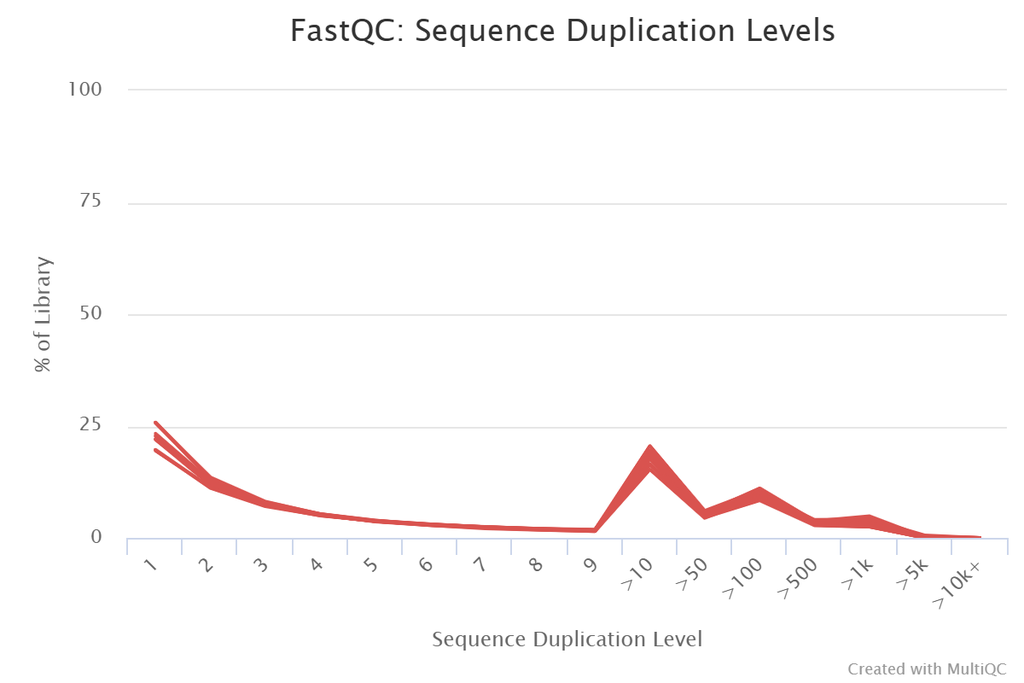

Secuencias duplicadas de los datos procesados

Se encuentra un sesgo en las primeras 15 bases en la gráfica de contenido por base, sin embargo, se reporta que es normal para RNA-seq.

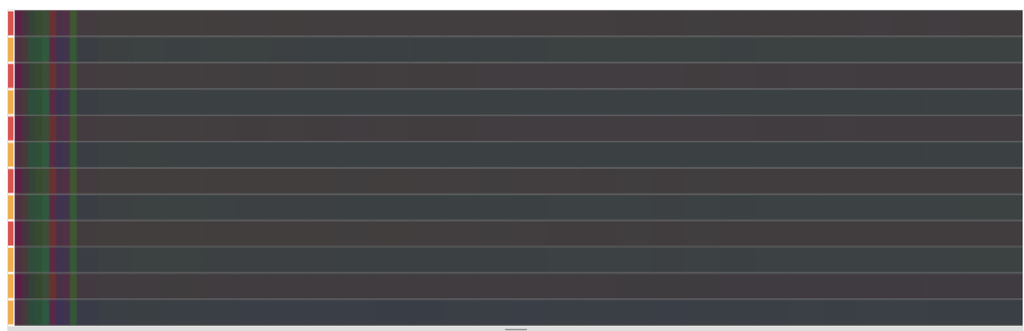

Contenido por base

### Conclusión de la calidad de datos procesados

El procesamiento de los datos utilizando `trimmomatic` redujo la cobertura de las secuencias, indicativo que removió lecturas de mala calidad, y todos los reads pasaron la prueba de contenido de adaptadores, por lo cuál indica que fueron removidos.

El tamaño de las reads iniciales (datos crudos) y las finales (datos procesados) se mantuvo igual.

## 5. Generar index de STAR

Antes de realizar el alineamiento de las secuencias, es fundamental realizar el indexado para acceder a los datos de forma más eficiente. Para ello se obtuvo el genoma de referencia humano desde NCBI, versión *GRCh38.p14*, en formato FASTA (secuencia) y GTF (anotaciones).

El genoma y anotaciones se almacenaron dentro del cluster, en la ruta `/mnt/data/bioinfo-estadistica-2/RNAseq_2026/equipos/Equipo2/reference`

Posteriormente, se realizó el indexado con STAR, utilizando los siguientes parámetros:

- `--run ThreadN 30` Usa 30 threads en paralelo para mayor velocidad
- `--runMode genomeGenerate` Genera el índice del genoma
- `--genomeDir ./align/STAR/STAR_index` Indica ruta donde se guardarán los índices
- `--genomeFastaFiles` Recibe el archivo FASTA del genoma de referencia
- `--sjdbGTFfile` Recibe el archivo GTF del genoma de referencia
- `--sjdbOverhang` Define el tamaño de la secuencia alrededor de los splice junction (punto de unión entre dos exones), el valor óptimo es `longitud read - 1`

El script correspondiente se puede encontrar dentro del GitHub, en la ruta scripts/05_STAR_index.sh

Los resultados del indexado, se almacenaron en el cluster, en la ruta `/mnt/data/bioinfo-estadistica-2/RNAseq_2026/equipos/Equipo2/align/STAR/STAR_index`

## 6. Alineamiento de secuencias con STAR

Se realizó el alineamiento de las secuencias con STAR, debido a su alta precisión y velocidad de mapeo. Para ello, se utilizaron las secuencias de los datos procesados y el índice previamente generado. Además, se realizó el conteo de las lecturas por genes. Se utilizaron los siguientes parámetros:

- `--runThreadN 12` Usa 12 threads en paralelo para mayor velocidad
- `--genomeDir` Recibe la ruta del índice
- `--readFilesIn` Recibe las secuencias de los datos procesados (ambas lecturas paired-end)
- `--outSAMtype BAM SortedByCoordinate` Convierte archivo de salida SAM a BAM y ordenados por posición en el cromosoma
- `--quantMode GeneCounts` Cuenta lecturas por genes
- `--readFilesCommand zcat` Descomprime datos mientras los analiza
- `--outFileNamePrefix` Define ruta donde se guardan resultados por muestra

El script correspondiente se puede encontrar dentro del GitHub, en la ruta scripts/06_STAR_align.sh

Los resultados del alineamiento, se almacenaron en el cluster, en la ruta `/mnt/data/bioinfo-estadistica-2/RNAseq_2026/equipos/Equipo2/align/STAR/STAR_output`

## 7. Importar datos de cuentas en R

Posterior al alineamiento con STAR, es necesario importar los datos provenientes de este a R para el posterior análisis de Expresion diferencial con DESEq2. En nuestro caso, realizamos el análisis con R versión 4.4.1 dentro del cluster.

El script correspondiente al alineamiento se puede encontrar dentro del GitHub, en la ruta scripts/07_Load_data_STAR.R

Al terminar este script, contamos con una matriz de cuentas crudas de los datos y cargamos los metadatos. Ambos se encuentran en la ruta de github `results/counts/raw_counts.RData` como un dataset de R para cargar.

Y, dentro del cluster, en la ruta `/mnt/data/bioinfo-estadistica-2/RNAseq_2026/equipos/Equipo2/results/counts`

## 8. Análisis de expresión diferencial de genes (DEGs)

Cargamos nuestra matriz de cuentas crudas generada y la metadata para, posteriormente, seleccionar los genes con más de 10 cuentas.

Al convertirlas al formato dds, observamos que teníamos 6 muestras y 17,266 genes hasta este punto. Para después realizar las comparaciones, indicando cual es la referencia (“WT”). Guardamos el resultado de la salida en el archivo `results/STEAP3_KD_vs_WT.RData` el cual contiene la metadata y el archivo dds.

Posteriormente, se realizó la normalización de los datos para que poder comparar los niveles de expresión entre muestras, evitando sesgos técnicos y biológicos. Utilizamos la función rlog debido a que tenemos pocas muestras (<30).

Con el objeto resultante, se realizó un PCA con el objetivo de detectar batch effect. De esta forma, se observó que las 3 muestras con la condición Knockdown *STEAP3* se agrupan, mientras que las 2 de las WT se agrupan y la muestra restante se aleja de los dos clusters.

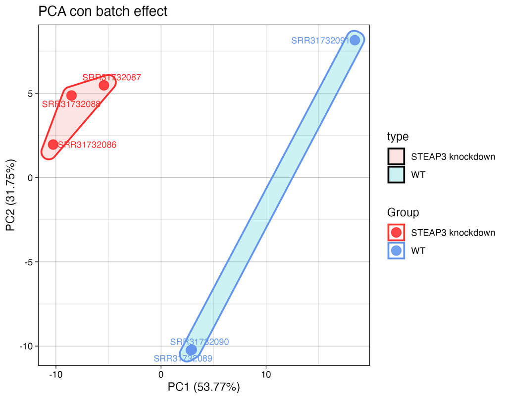

PCA antes de corrección por *batch effect*

Al realizar la corrección por el batch effect con Limma, se obtiene la misma gráfica y no se genera la columna `$batch` en el objeto generado por DESeq2, por lo que se concluye que no existe batch effect y probablemente existe una dispersión de los datos para las muestras WT que no puede visualizarse debido a la poca cantidad de muestras (3).

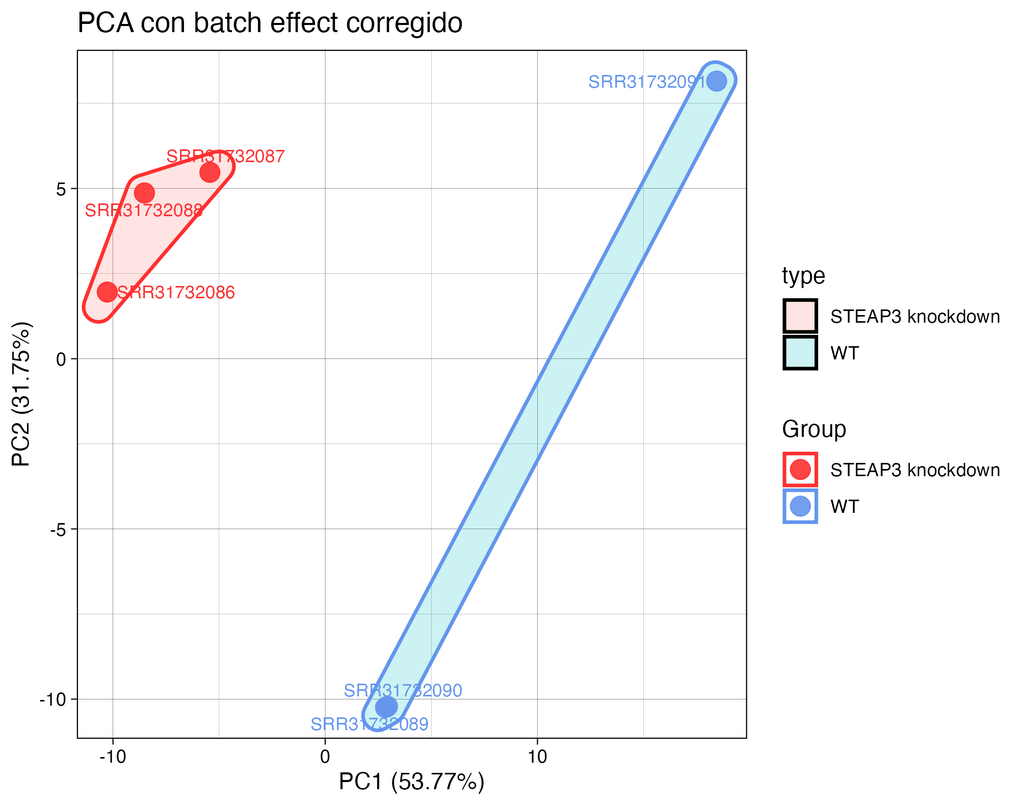

PCA después de corrección por *batch effect*

Finalmente, se obtuvo la información de las muestras con el único contraste entre Wild-Type y Knockdown, que se guardó en el archivo `results/DE_KD_vs_WT.csv`. En el resumen de este, podemos observar que dentro de los 17,266 genes previamente filtrados hubieron:

- 744 con un LFC > 0 (sobreexpresados)
- 825 con un LFC < 0 (subexpresados)
- 0 outliers
- 4687 con pocas cuentas

El script correspondiente se puede encontrar dentro del GitHub, en la ruta scripts/08_DEG_STAR_KD.R

## 9. Visualización de los datos DEG

En primera instancia, se filtraron los genes que tuvieran un p-valor ajustado menor a 0.05. Además, se clasificaron como sobreexpresados cuando tuvieran LFC ≥ 2, y como subexpresados con LFC ≤ 2.

Algunas de las gráficas generadas a partir de los datos de los genes con expresión diferenciada (DEG) se muestran a continuación. Para generarlas se utilizaron los paquetes de `ggplot2` y `pheatmap`

El script correspondiente se puede encontrar dentro del GitHub, en la ruta scripts/09_Visualization_data_STAR.R

Las gráficas generadas en este paso y el siguiente se guardaron en el cluster, en la ruta `/mnt/data/bioinfo-estadistica-2/RNAseq_2026/equipos/Equipo2/results/figures`

### Volcano Plot

Para el Volcano Plot, observamos 3 genes subexpresados y 12 genes sobreexpresados. El gen subexpresados con mayor p-value es *STEAP3* y el gen sobreexpresado con mayor p-value es *SERPINB3*.

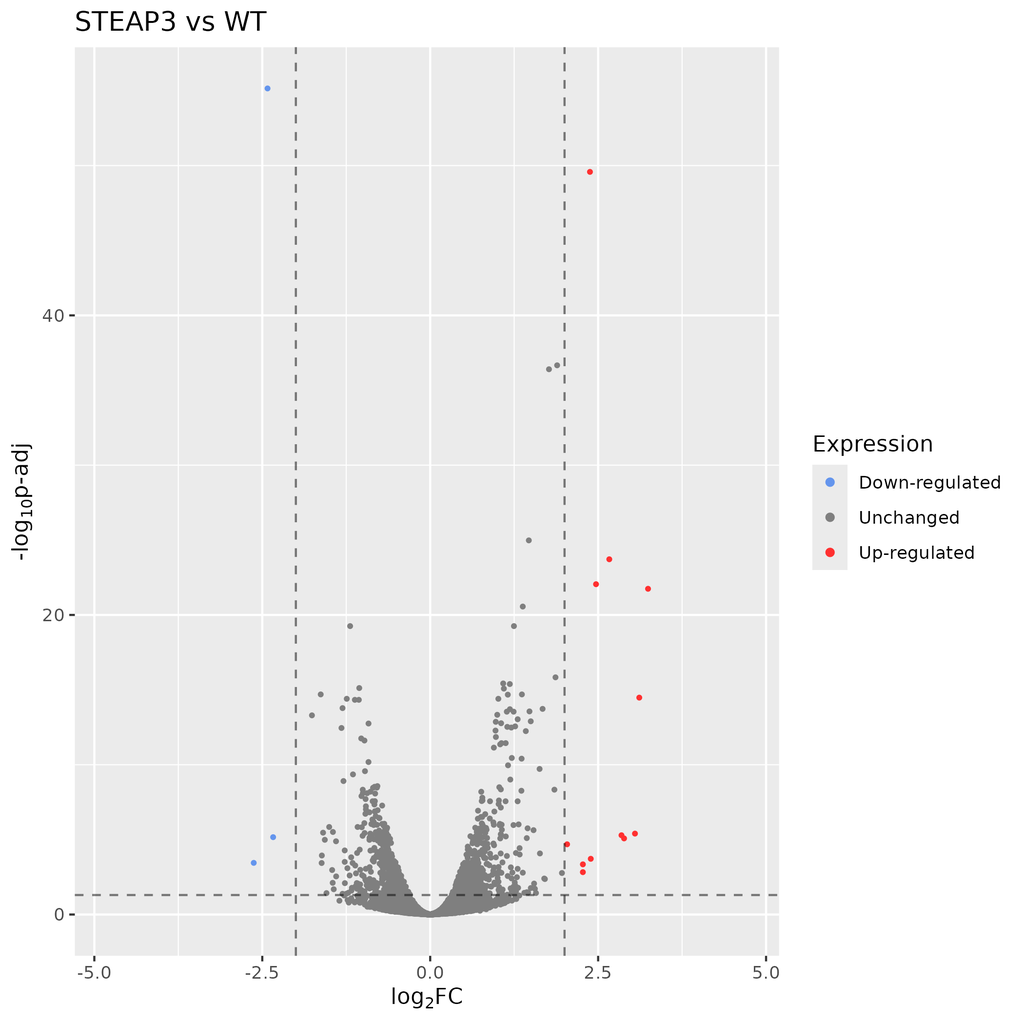

Volcano Plot

### Heatmap

Por otro lado, realizamos un Heatmap, donde obtuvimos los 20 genes con el p-valor más significativo, y creamos un filtro donde el Log Fold Change máximo fuera 3, de esta manera evitamos sesgar los resultados por los outliers.

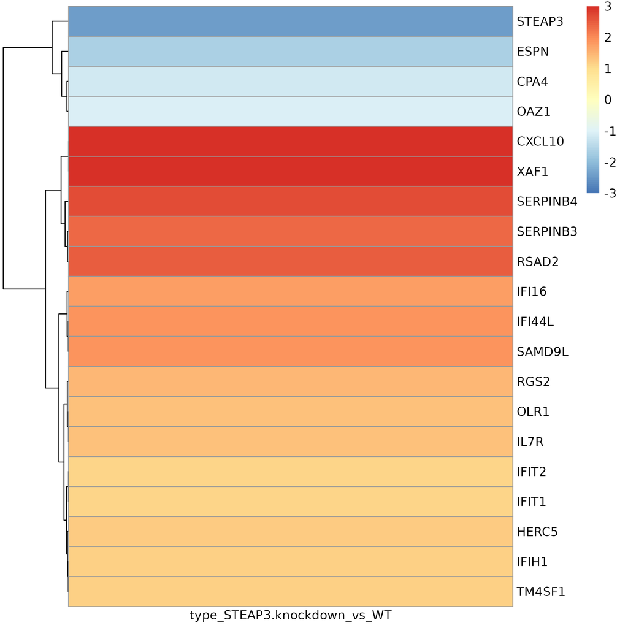

Heatmap

## 10. Análisis funcional con términos GO

Se realizó el mismo filtrado que realizamos en la sección de “Visualización de los datos” para realizar las gráficas.. Posteriormente, realizamos la determinación funcional de los genes diferencialmente expresados a partir de los datos.

El script correspondiente se puede encontrar dentro del GitHub, en la ruta scripts/10_GO_terms_STAR.R

### Manhattan plot

Primero, realizamos un Manhattan plot. Mediante este plot podemos observar la cantidad de vías metabólicas observadas en cada base de datos, representadas por un punto del color correspondiente.

Las bases de datos que escogimos fueron: Gene Ontology - Biological Process (GO:BP), KEGG, Reactome (REAC), Transfac (TF), miRTarBase (MIRNA), Human Protein Atlas (HPA), CORUM, Human Phenotype Ontology (HP) y WikiPathways (WP).

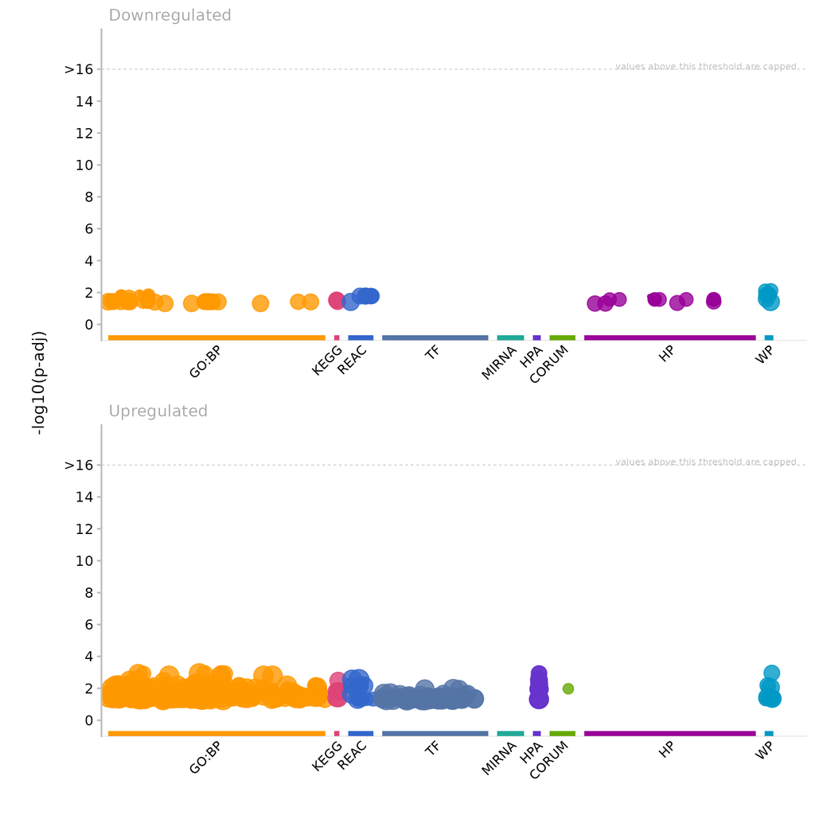

Manhattan Plot

### Gráficas de barras de genes sobreexpresados y subexpresados

Por otro lado, también podemos realizar una gráfica de barras con la información de los genes subexpresados, ordenados por su p-valor y categoría. En esta gráfica podemos observar las vías metabólicas relacionadas a los genes subexpresados, y de igual forma de que base de datos provienen cada una de ellas.

Algunas vías relacionadas a los genes que disminuyen su expresión son:

- **Ferroptosis**: una forma de muerte celular programada dependiente de hierro.
- **Metabolismo del cobre y hierro:** importación de iones de cobre y hierro, concentración epática elevada de hierro, transporte y abosrbción de hierro, metabolismo del hierro en la placenta, desórdenes del metabolismo del hierro, homesotasis del cobre, saturación de la transferina (proteína que transporta hierro)
- **Crecimiento** celular y regulación de *TP53*
- **Contracción muscular**: contracción del corazón, músculo liso de la vena, músculo liso arterial, músculo liso tónico, etc
- **Ciclos de GTPasas:** *RHOJ*, *RHOO*, *RHOF*, *RHOD*

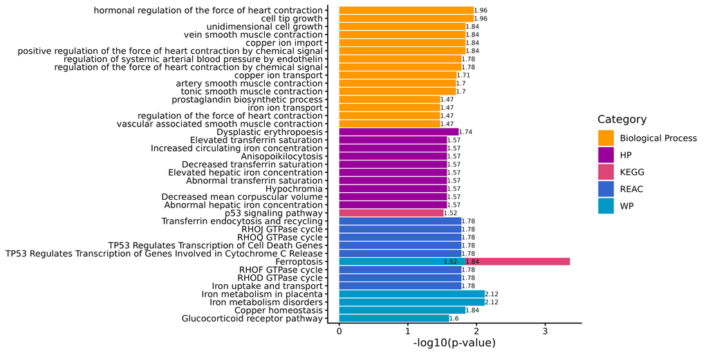

Gráfica de barras de rutas metabólicas relacionadas a genes subexpresados

De igual forma podemos observar las vías metabólicas relacionadas a los genes sobreexpresados. Algunas vías son:

- **Proteólisis**: regulación negativa de actividad de peptidasas, hidrolasas, actividad catalítica y funciones moleculares
- **Respuesta inmune:** respuesta a virus, respuesta simbionte, respuesta a otros organismos, estímulos bióticos o estímulos externos, respuesta de defensa, regulación del sistema inmune, regulación de linfocitos, respuesta a estrés, señalización autócrina y parácrina

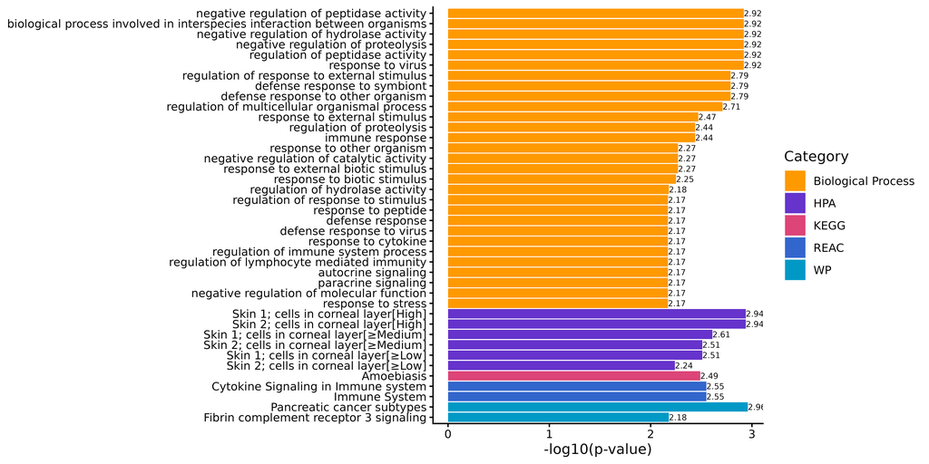

Gráfica de barras de rutas metabólicas relacionadas a genes sobreexpresados

# Discusión

La siguiente tabla pertenece a una tabla suplementaria del artículo en la cual enlista todos los DEGs, su Log2FoldChange, p-value y FDR.

| Gene | FC | Log2 FC | P value | FDR |
| --- | --- | --- | --- | --- |
| STEAP3 | 0.18 | -2.46 | 0 | 0 |
| SERPINB3 | 5.29 | 2.4 | 0 | 0 |
| IFI44L | 3.77 | 1.92 | 0 | 0 |
| IFI16 | 3.53 | 1.82 | 0 | 0 |
| SERPINB4 | 6.32 | 2.66 | 0 | 0 |
| RGS2 | 2.8 | 1.48 | 0 | 0 |
| CXCL10 | 9.87 | 3.3 | 0 | 0 |
| RSAD2 | 5.79 | 2.53 | 0 | 0 |
| OLR1 | 2.67 | 1.41 | 0 | 0 |
| CPA4 | 0.44 | -1.17 | 0 | 0 |

[output cut: 232 more lines]

El volcano plot que se realizó en el artículo presenta todos sus DEGs, resaltando que los mismos genes con mayor p-value de cada grupo coinciden con los reportados en nuestro trabajo.

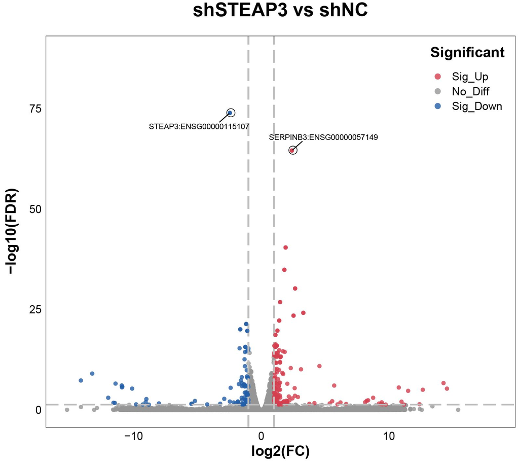

Volcano Plot del artículo “Silencing of *STEAP3* suppresses cervical cancer cell proliferation and migration via JAK/STAT3 signaling pathway.”

Además el artículo presenta un dotplot en el cual se visualizan las 20 rutas más enriquecidas en KEGG, de la cual destacan la Vía de señalización JAK-STAT. Hacen énfasis debido a la participación del gen *STEAP3* ya que debido a diversos estudios en los cuales se realizaron mediciones de la expresión del gen y de marcas de metilación en la secuencia del gen en tejido de cáncer cervical, muestran significancia en comparación a una condición celular normal; además que encontraron una asociación con la capacidad de migración de las células cancerígenas en función de la expresión de este gen.

Sin embargo, al contrario de ellos, debido a nuestro reducido número de DEGs, dicha vía de señalización no se encuentra enriquecida en nuestro análisis.

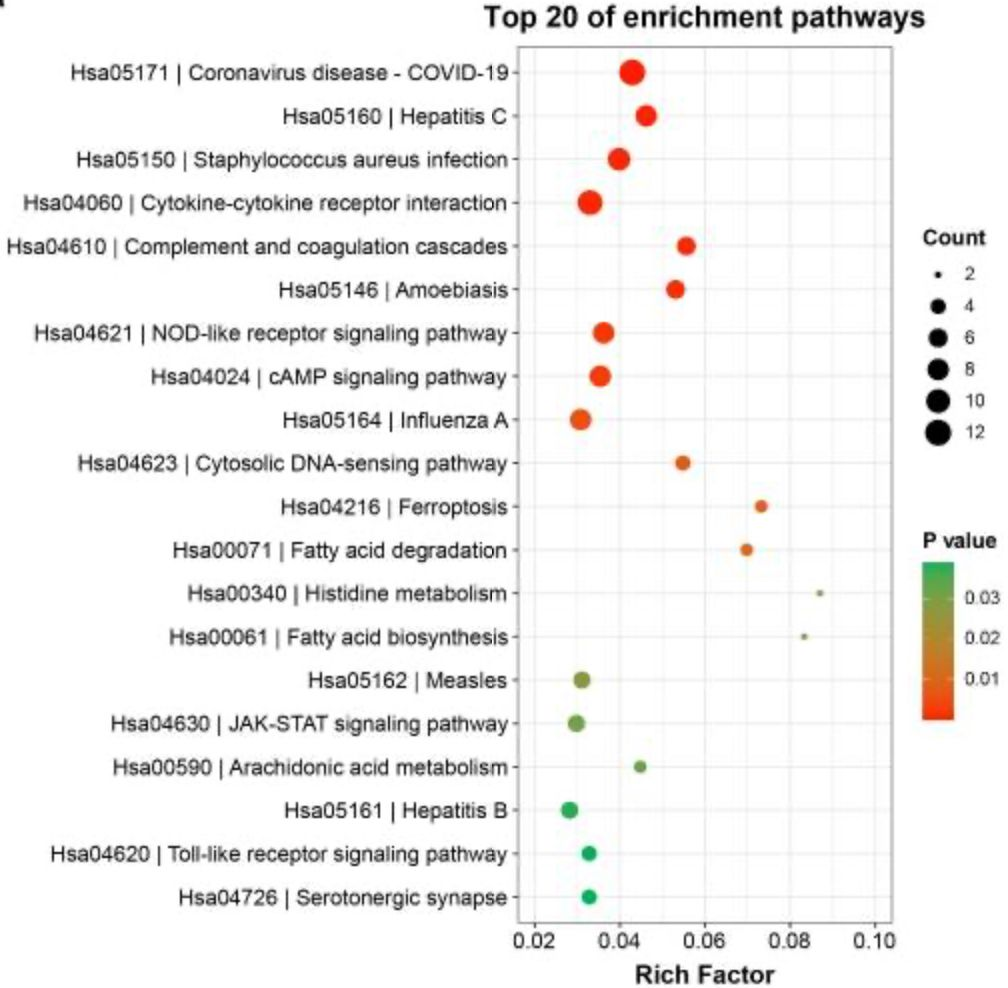

Dotplot del artículo “Silencing of *STEAP3* suppresses cervical cancer cell proliferation and migration via JAK/STAT3 signaling pathway.”

Por otro lado, la importancia de la expresión de *STEAP3* no solo ha sido reportada para el cáncer de cuello uterino. Como se menciona en Han, Y., *et al*., cuando *STEAP3* se encuentra sobreexpresado en tejidos de cáncer de ovarios, se reporta una menor supervivencia.

Por lo tanto, mediante experimentos *in vitro* se demostró que al silenciar *STEAP3* disminuye la proliferación, migración y capacidad invasiva de células tumorales, esto al desencadenar procesos de ferroptosis en las células cancerosas.

Un aspecto relevante es que existe una correlación negativa entre *STEAP3* y p53. Donde, al silenciar *STEAP3*, los niveles de p53 aumentan, inhibiendo la expresión de *SLC7A11*, induciendo la ferroptosis.

Con ello, podemos concluir que el silenciamiento de *STEAP3* puede inhibir el crecimiento de diversos tumores y que puede hacerlo mediante vías distintas a JAK-STAT.

Referente a los otros genes que tenían una expresión diferenciada, pudimos complementar nuestro análisis al informarnos de otras funciones de algunos genes y la relación con el cáncer cervical reportada en la literatura.

Primeramente, los genes *SERPINB3* y *SERPINB4* son los genes sobreexpresados que presentan un mayor p-value y tienen homología divirgiendo principalmente en loop del sitio reactivo (RSL) en la región de carboxyl terminal. Particularmente, *SERPINB3* es un inhibidor de proteasa de cisteína intracelular que se ha reportado sobreexpresado en cáncer.

En el estudio realizado por Wang, S., *et al.* se mostró que las células de cáncer cervical son más sensibles a tratamiento, esto debido a que este gen tiene funciones de protección ante daño lisosomal y muerte organismal al inhibir la actividad de proteasa de cisteína inducida por estreses como daño al DNA y especies reactivas de oxígeno.

Por otro lado, podemos analizar la relación de la sobreexpresión de *CXCL10* con la supresión de la proliferación celular.

De acuerdo con Li, X., *et al.* donde se creo un adenovirus oncolítico recombinante modificado genéticamente para expresar la quimiocina *CXCL10*, la expresión continua de *CXCL10* en el interior del tumor, atrae a las células T, que expresan el receptor *CXCR3* (ubicado en la superficie de los linfocitos T citotóxicos CD8+ y CD4+).

Por lo tanto, la terapia con *CXCL10* suprime el crecimiento del tumor, incrementando la infiltración de células T en el microambiente tumoral.

Podemos concluir que la sobreexpresión de este gen es coherente como una respuesta de la célula para suprimir la proliferación celular.

Algunas limitaciones de nuestro análisis fue que se utilizaron diferentes programas en el desarrollo de nuestro análisis, comparado con el artículo de referencia. Esto redujo la cantidad de DEGs, por lo que no se tuvieron resultados iguales. Sin embargo, logramos identificar algunas similitudes en las rutas enriquecidas como ferroptosis. Creemos que se podría mejorar el análisis al incorporar elementos de su flujo de trabajo, pero manteniendo los criterios establecidos para un análisis de calidad. De igual forma, podríamos mejorar nuestro trabajo al emplear flujos de trabajo de Nextflow.

Otra limitación sería la poca cantidad de muestras obtenidas en el experimento. Tener más muestras biológicas nos podría ayudar a que se delimitaran más las diferencias entre muestras de un mismo grupo, como se vio en el grupo control al analizar el PCA del batch effect. Esto nos ayudaría a que nuestro análisis fuera más robusto.

# Referencias

- Zhao, Z., Yu, P., Wang, Y., Li, H., Qiao, H., Sun, C., Zhu, L., & Yang, P. (2024). Silencing of *STEAP3* suppresses cervical cancer cell proliferation and migration via JAK/STAT3 signaling pathway. *Cancer & metabolism*, *12*(1), 40. https://doi.org/10.1186/s40170-024-00370-2
- Terán, M., Mónaco, M., Haro, C., Ledesma, M. *et al*. Ferroptosis, un mecanismo de muerte celular presente en β-talasemia menor. (2024). *Revista Bioquímica Y Patología Clínica*, *89*(1), 19-26. https://doi.org/10.62073/k7g1yk82
- Han, Y., Fu, L., Kong, Y., Jiang, C., Huang, L., & Zhang, H. (2024). STEAP3 Affects Ovarian Cancer Progression by Regulating Ferroptosis through the p53/SLC7A11 Pathway. *Mediators of inflammation*, *2024*, 4048527. https://doi.org/10.1155/2024/4048527
- Wang, S., Luke, C.J., Pak, S.C. *et al.* SERPINB3 (SCCA1) inhibits cathepsin L and lysoptosis, protecting cervical cancer cells from chemoradiation. *Commun Biol* **5**, 46 (2022). https://doi.org/10.1038/s42003-021-02893-6
- Li, X., Lu, M., Yuan, M., Ye, J., Zhang, W., Xu, L., Wu, X., Hui, B., Yang, Y., Wei, B., Guo, C., Wei, M., Dong, J., Wu, X., & Gu, Y. (2022). CXCL10-armed oncolytic adenovirus promotes tumor-infiltrating T-cell chemotaxis to enhance anti-PD-1 therapy. *Oncoimmunology*, *11*(1), 2118210. https://doi.org/10.1080/2162402X.2022.2118210